# Creating a Map Using ggplot2

MTH 209 Data Manipulation and Management

Ying-Ju Tessa Chen

Department of Mathematics, University of Dayton

## Overview

A map connects a geographic region to information about that region.

We will follow the original sequence:

- World map and selected countries
- World choropleth
- U.S. states and interactive maps
- Ohio counties
- Bubble map

## Packages and Map Data

### Packages

```r
library(tidyverse)
library(maps)
library(viridis)
```

### Boundary data

```
map_data(map, region = ".", exact = FALSE, ...)
```

### The drawing ingredients

| Field | Role |
| --- | --- |
| `long`, `lat` | Boundary coordinates |
| `group` | Separate polygons and islands |
| `region` | Country or state name |

- `ggplot2::map_data()` retrieves boundaries from the **maps** package.
- Use `"world"`, `"state"`, or `"county"` to choose the database.
- `region` selects a subset.
- `exact = FALSE` treats it as a pattern;
- `exact = TRUE` requests an exact database-name match.

Later, **usmap** supplies geometry for `geom_sf()`.

## Drawing Boundaries with geom_polygon()

### Coordinates form polygons

```r
ggplot(map, aes(long, lat, group = group)) +
  geom_polygon(
    fill = "lightblue",
    colour = "white",
    linewidth = 0.15
  )
```

`geom_polygon()` connects each group of boundary vertices and closes its outline. Keep the vertices in their original order.

### The new mapping arguments

| Code | Meaning |
| --- | --- |
| `long`, `lat` | Longitude and latitude of boundary vertices |
| `group = group` | Which vertices belong to each separate polygon |
| `fill` | Interior color |
| `colour` | Boundary color |
| `linewidth` | Boundary thickness |

**Why group matters:** islands can be separate polygons within the same country. Grouping only by country can connect unrelated pieces.

## A Simple World Map

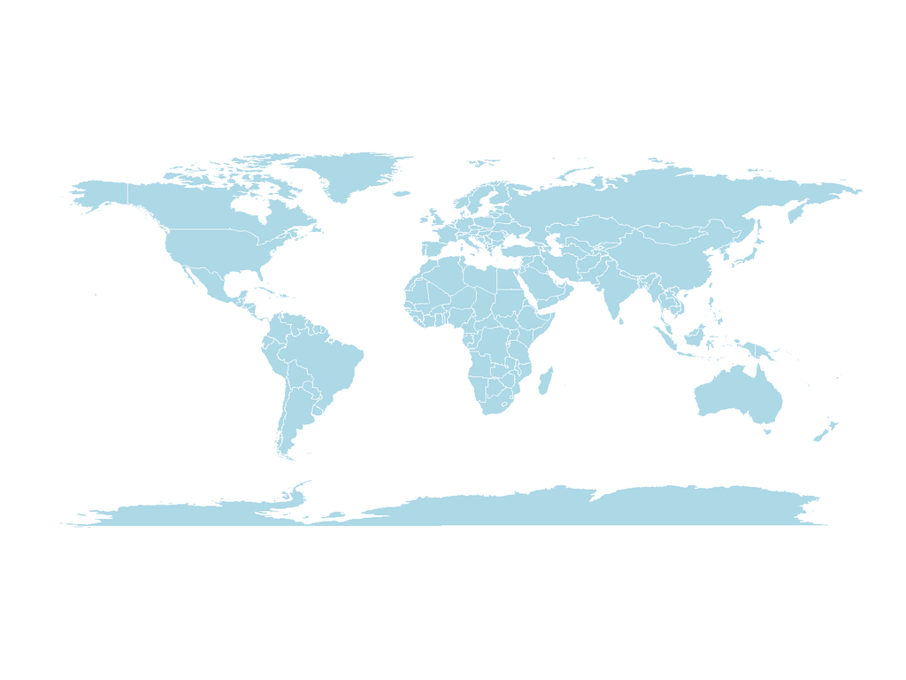

```r
map <- map_data("world")

world_plot <- ggplot(
  map, aes(long, lat, group = group)) +
  geom_polygon(fill = "lightblue",
               colour = "white",
               linewidth = 0.15) +
  coord_quickmap() +
  theme_void()

world_plot
```

- `coord_quickmap()` adjusts the aspect ratio for an approximate longitude/latitude map. It does not calculate a full map projection.
- `theme_void()` removes axes, ticks, and the background grid.

## A Map for Specific Regions

```r
East_Asia <- c(
  "China", "Japan", "Mongolia", "North Korea",
  "South Korea", "Taiwan"
)

East_Asia_map <- map %>%
  filter(region %in% East_Asia)

region_data <- East_Asia_map %>%
  group_by(region) %>%
  summarise(long = mean(long),
            lat = mean(lat)) %>%
  mutate(label_color = if_else(
    region %in% c("China", "Japan", "Mongolia"),
    "white", "black"))
```

### Selected boundaries

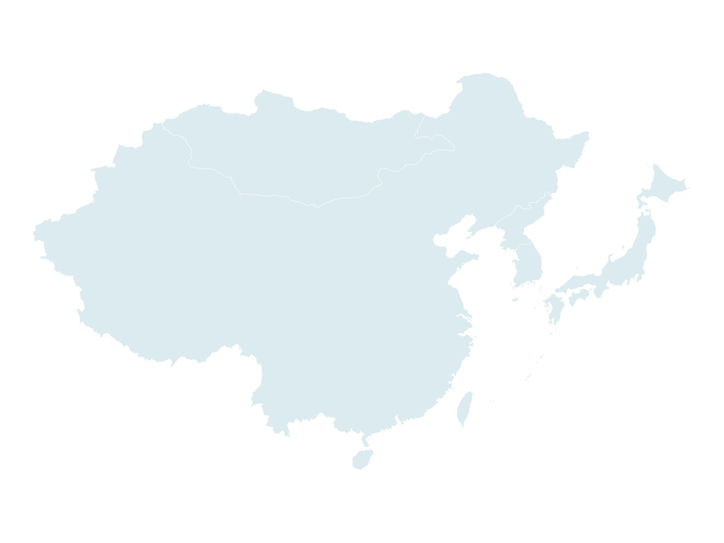

The mean boundary coordinates give **approximate label locations**. These are not geographic centroids.

## Map Labels and Color Scales

### A separate dataset for labels

```r
geom_text(
  data = region_data,
  aes(label = region, colour = label_color)
) +
scale_colour_identity()
```

Boundary data contain many rows per region.

- `region_data` has **one label position per region**, so the layer prints each name once.
- `scale_colour_identity()` uses stored color values such as `"white"` directly.

### Discrete and continuous colors

| Function | Appropriate values |
| --- | --- |
| `scale_fill_viridis_d()` | Categories, such as country names |
| `scale_fill_viridis_c()` | Numbers, such as litres per person |

- `option` selects a palette, for example `"B"` or `"H"`. It changes the colors, not the statistics.
- `na.value = "grey85"` gives missing values a separate gray color. **Missing does not mean zero.**

## Labels and Categorical Fill

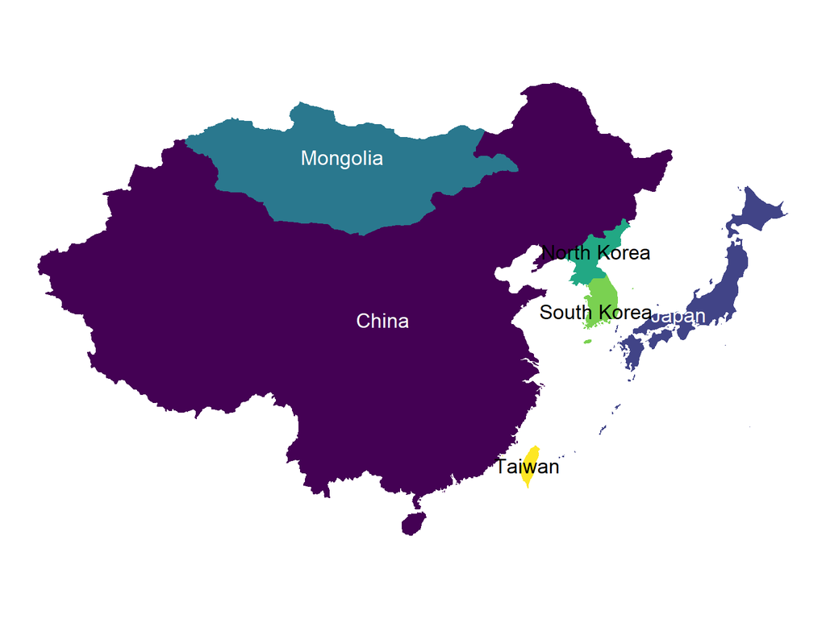

```r
asia_plot <- ggplot(East_Asia_map, aes(long, lat)) +
  geom_polygon(aes(group = group,
                   fill = region)) +
  geom_text(data = region_data,
            aes(label = region, colour = label_color),
            size = 5) +
  scale_colour_identity() +
  scale_fill_viridis_d() +
  coord_quickmap() +
  theme_void() +
  theme(legend.position = "none")

asia_plot
```

## A Choropleth Map: Data

A **choropleth** represents a variable using the fill color of each region.

```r
drinks <- read_csv("drinks.csv")

# Lesson helper: country-name correspondences.
country_names <- read_csv(
  "country_name_lookup.csv"
)
```

The lookup connects alternative country names. Separate island regions can share one country record.

### A first look at the data

| Country | Litres / person |
| --- | --- |
| Afghanistan | 0.0 |
| Albania | 4.9 |
| Algeria | 0.7 |
| Andorra | 12.4 |
| Angola | 5.9 |
| Antigua & Barbuda | 4.9 |

Historical teaching data: **2010**.

[FiveThirtyEight / WHO GISAH](https://github.com/fivethirtyeight/data/tree/master/alcohol-consumption).

## Why a Country-Name Lookup File?

### The same country, different names

`left_join()` matches text exactly. These pairs refer to the same country but do not match as written.

| In `drinks.csv` | In the map boundaries |
| --- | --- |
| Russian Federation | Russia |
| United Kingdom | UK |
| Cote d’Ivoire | Ivory Coast |

Without a correspondence, the map would show missing alcohol statistics for these regions.

### A transparent lesson helper

**`country_name_lookup.csv` was created for this lesson with Codex**, by comparing names in the two sources. It is a manually prepared correspondence table, not an official downloaded dataset.

- `region` is the name used by the boundary database.
- `country` is the name used by `drinks.csv`.
- Separate island regions can share one country record.

Keeping the small lookup separate makes the changes visible and reusable while preserving the original data. Students can open the CSV and inspect every pairing.

## Country Names and the Join

```r
map_keys <- map %>%
  distinct(region) %>%
  left_join(country_names, by = "region") %>%
  mutate(country = coalesce(country, region))

drinks_map <- map %>%
  left_join(map_keys, by = "region") %>%
  left_join(drinks, by = "country")

# Checking the Country Match
unmatched_countries <- drinks %>%
  anti_join(map_keys, by = "country") %>%
  select(country)

unmatched_countries
```

### Checking the match

| No matching boundary |
| --- |
| Tuvalu |

Start with the **boundaries** to preserve polygon order and keep regions without statistics.

- `coalesce(country, region)` uses the original region name when the lookup has no alternative.
- `anti_join()` identifies data rows without a matching key. An absent boundary needs another map source.

**Tuvalu** has no region in this database. Missing statistics appear in gray.

## A Choropleth Map

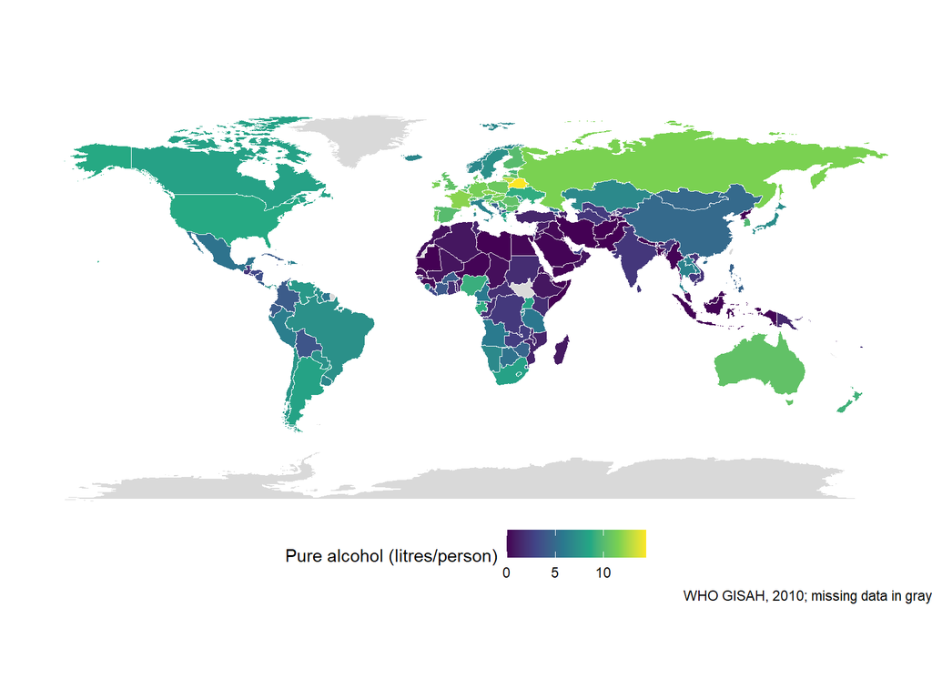

```r
world_drinks <- ggplot(
  drinks_map, aes(long, lat, group = group)) +
  geom_polygon(
    aes(fill = total_litres_of_pure_alcohol),
    colour = "white", linewidth = 0.1
  ) +
  scale_fill_viridis_c(na.value = "grey85") +
  coord_quickmap() +
  labs(fill = "Pure alcohol (litres/person)",
       caption = "WHO GISAH, 2010; missing data in gray") +
  theme_void() +
  theme(legend.position = "bottom")

world_drinks
```

## A U.S. State-Level Map: Labels

```r
US_map <- map_data("state")

state_lookup <- tibble(
  region = tolower(state.name),
  region_abb = state.abb
)

state_data <- US_map %>%
  group_by(region) %>%
  summarise(long = mean(long),
            lat = mean(lat)) %>%
  inner_join(state_lookup, by = "region")
```

### Names connect the labels

| Region key | Label |
| --- | --- |
| alabama | AL |
| alaska | AK |
| arizona | AZ |
| arkansas | AR |
| california | CA |
| colorado | CO |

Join by state name rather than relying on row order.

This database shows the **contiguous United States**. Overlapping labels are omitted on the next map.

## A U.S. State-Level Map

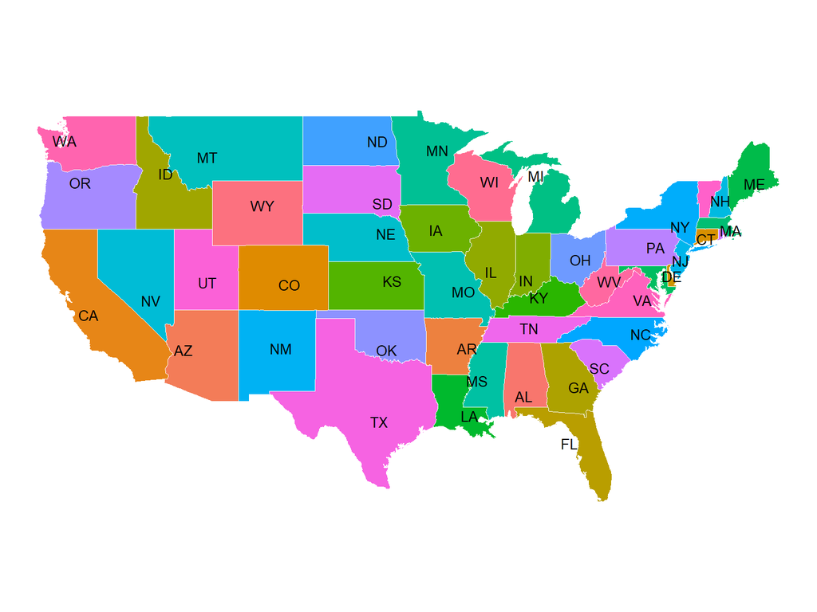

```r
p <- ggplot(US_map, aes(long, lat)) +
  geom_polygon(aes(group = group,
                   fill = region),
               colour = "white",
               linewidth = 0.2) +
  geom_text(data = state_data,
            aes(label = region_abb),
            size = 3.5, check_overlap = TRUE) +
  coord_quickmap() +
  theme_void() +
  theme(legend.position = "none")

p
```

`check_overlap = TRUE` skips labels that would overlap an earlier label. It does not move the label positions or remove states from the map.

## Plotly: Conversion and Figure Size

### Convert a finished ggplot

```r
ggplotly(p, height = 540) %>%
  config(responsive = TRUE)
```

- `p` is an existing ggplot object. `ggplotly()` converts it to an HTML widget with pointer interaction.
- `config()` sets the widget’s interaction and display options.

### Size and browser behavior

| Argument | Effect |
| --- | --- |
| `height = 540` | Figure height in pixels |
| `width = 700` | Optional fixed width in pixels |
| `responsive = TRUE` | Allow resizing with the browser |

We leave `width` unspecified so the map can fit its slide column. The slide also refits widgets when a page becomes visible.

**Try:** increase `height` to 620. The map gains vertical space; the data do not change.

## A Dynamic Map Using plotly - 1

`ggplotly()` adds interaction to a ggplot object. Move the pointer over the map to inspect the available information.

```r
library(plotly)

ggplotly(p, height = 540) %>%
  config(responsive = TRUE)
```

[interactive chart not shown]

## Plotly: Custom Hover Text

### Define the text in a layer

```r
aes(
  group = group,
  fill = region,
  text = str_to_title(region)
)
```

- `text` stores the message for each region. Here, `str_to_title()` changes `"ohio"` to `"Ohio"`.
- A static ggplot may warn that `text` is an unknown aesthetic. Plotly reads it during conversion.

### Select it during conversion

```r
ggplotly(
  g, tooltip = "text", height = 540
)
```

- `tooltip = "text"` displays the custom text instead of the default collection of mapped values.

For statistics, construct a message such as:

```r
paste0(full, ": ", Murder,
       " arrests per 100,000 (1973)")
```

- `paste0()` combines text and values without adding spaces automatically.

## A Dynamic Map Using plotly - 2

A custom tooltip can show the state name over the whole polygon.

```r
g <- ggplot(US_map, aes(long, lat)) +
  geom_polygon(
    aes(group = group, fill = region,
        text = str_to_title(region)),
    colour = "white", linewidth = 0.2
  ) +
  coord_quickmap() +
  theme_void() +
  theme(legend.position = "none")

ggplotly(g, tooltip = "text", height = 540) %>%
  config(responsive = TRUE)
```

[interactive chart not shown]

## A Dynamic Map Using plotly - 3: Data

```r
library(usmap)
library(sf)

US_sf <- us_map("state") %>%
  filter(full %in% state.name)

crimes <- tibble(
  region = rownames(USArrests), USArrests
)
crimes_map <- US_sf %>%
  left_join(crimes, by = c("full" = "region"))
```

### Geography and statistics

| State | Murder arrests / 100,000 |
| --- | --- |
| Alabama | 13.2 |
| Alaska | 10.0 |
| Arizona | 8.1 |
| Arkansas | 8.8 |
| California | 9.0 |

`us_map("state")` selects state boundaries. **usmap** includes Alaska and Hawaii as insets.

An **sf object** stores the boundary coordinates together in a geometry column. `geom_sf()` reads that column, so it needs no explicit `long`, `lat`, or `group`.

These are **1973 arrest rates**.

## A Dynamic Map Using plotly - 3

```r
g1 <- ggplot(crimes_map) +
  geom_sf(
    aes(fill = Murder,
        text = paste0(full, ": ", Murder,
                      " arrests per 100,000 (1973)")),
    colour = "white", linewidth = 0.2
  ) +
  scale_fill_viridis_c(option = "B") +
  labs(fill = "Arrests per 100,000",
       caption = "USArrests: 1973 arrest data") +
  theme_void()

ggplotly(g1, tooltip = "text", height = 540) %>%
  config(responsive = TRUE)
```

[interactive chart not shown]

## Plotly: Hover Labels and Controls

### Styling the hover box

```r
hover_style <- list(
  bgcolor = "#232F34",
  bordercolor = "transparent",
  font = list(family = "Arial",
              size = 15, color = "white")
)

style(widget, hoverlabel = hover_style)
```

- `widget` represents a converted Plotly figure. `style()` changes properties of its plotted traces, including hover labels.

### Appearance and interaction

| Argument | Meaning |
| --- | --- |
| `bgcolor` | Hover-box background color |
| `bordercolor` | Hover-box outline color |
| `font` | Font family, size in pixels, and text color |
| `hoverlabel` | The settings list passed to `style()` |

Later, `config(displayModeBar = FALSE)` hides the Plotly toolbar. **Hover information still works.**

**Try:** change `bgcolor` to `"white"` and the font color to `"black"`.

## A Dynamic Map Using plotly - 4

The hover label can use its own font and background. The map legend continues to explain the fill colors.

```r
hover_style <- list(
  bgcolor = "#232F34",
  bordercolor = "transparent",
  font = list(family = "Arial",
              size = 15, color = "white")
)

ggplotly(g1, tooltip = "text", height = 540) %>%
  style(hoverlabel = hover_style) %>%
  config(responsive = TRUE)
```

[interactive chart not shown]

## A County-Level Map - 1

```r
library(readxl)

poverty <- read_excel(
  "Poverty2023.xlsx",
  sheet = "Poverty Data 2023", skip = 4
)
```

```r
ohio_data <- poverty %>%
  filter(Stabr == "OH", FIPS_Code != "39000") %>%
  transmute(
    fips = FIPS_Code,
    county_name = Area_Name,
    poverty_count = POVALL_2023,
    poverty_pct = PCTPOVALL_2023,
    median_income = MEDHHINC_2023
  )
```

### From the workbook to 88 counties

**2023 Census SAIPE estimates**, compiled by USDA ERS.

Skip the first **four documentation rows**. Remove `39000`, the statewide aggregate.

| Field | Meaning |
| --- | --- |
| `fips` | County identifier, as text |
| `poverty_count` | People in poverty |
| `poverty_pct` | Percent in poverty |
| `median_income` | Median household income |

**13.2 means 13.2%**, not 0.132. The second worksheet defines the original fields.

## Ohio County Boundaries

```r
ohio_sf <- us_map("county", include = "OH") %>%
  st_transform(4326) %>%
  left_join(ohio_data, by = "fips")

stopifnot(
  nrow(ohio_sf) == 88,
  !anyDuplicated(ohio_data$fips),
  !anyNA(ohio_sf$poverty_pct)
)
```

- **Join key: FIPS**  
  Connect the datasets using county codes stored as text.
- **Select counties: `us_map()`**  
  Use `include = "OH"` to select Ohio counties.
- **Convert coordinates: `st_transform()`**  
  Use `4326` for WGS84 longitude and latitude.
- **Check the data: `stopifnot()`**  
  Check for 88 counties, unique keys, and no missing rates.

### Joined county boundaries

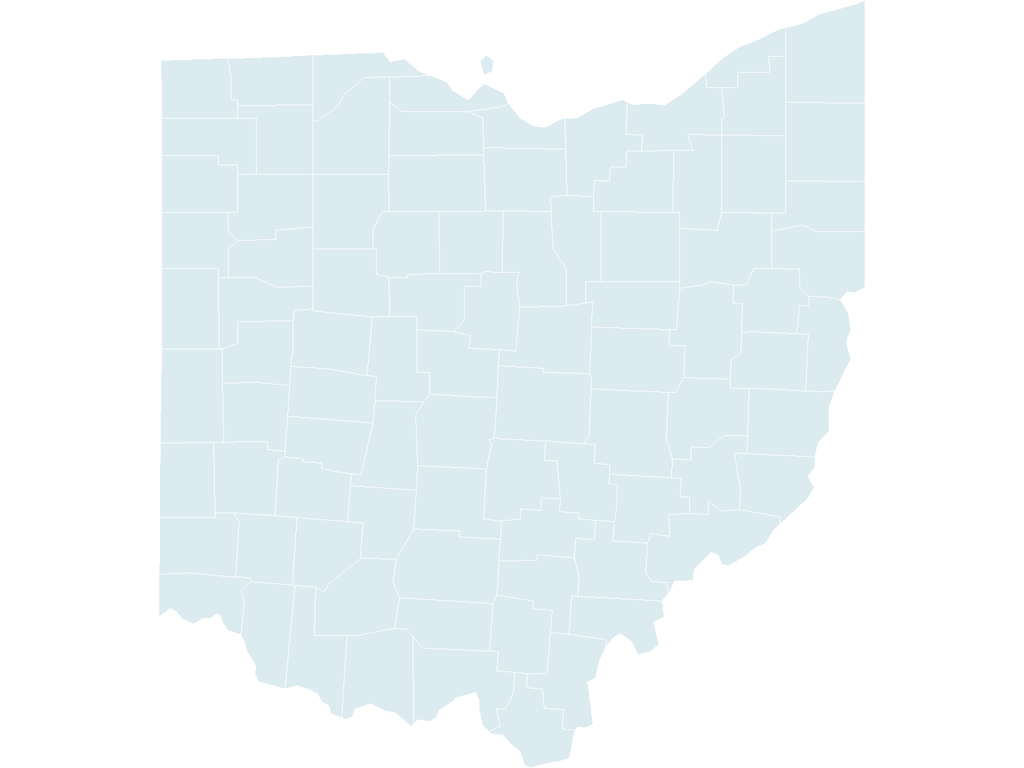

## Spatial Functions for Label Locations

### A reusable coordinate recipe

```r
ohio_sf %>%
  st_transform(32123) %>%
  st_point_on_surface() %>%
  st_transform(4326)
```

Use the projected system to calculate interior points, then convert them back for this map. The code numbers identify coordinate systems; students can reuse them.

### What the sf functions return

| Function | Result |
| --- | --- |
| `st_point_on_surface()` | One interior point per county feature |
| `st_coordinates()` | A matrix of point X and Y coordinates |
| `st_drop_geometry()` | An ordinary table without the geometry column |
| `st_crs(4326)` | The coordinate-system definition used by `coord_sf()` |

An interior point is a practical label anchor. It is not necessarily the centroid or the county seat.

## County Label Locations

```r
ohio_labels <- ohio_sf %>%
  st_transform(32123) %>%
  st_point_on_surface() %>%
  st_transform(4326)

label_xy <- st_coordinates(ohio_labels)
ohio_labels <- ohio_labels %>%
  st_drop_geometry() %>%
  mutate(
    long = label_xy[, 1], lat = label_xy[, 2],
    label = str_remove(county, " County$"),
    long = long + case_when(
      label == "Richland" ~ -0.07,
      label == "Ashland" ~ 0.06,
      TRUE ~ 0)
  )
```

### Interior label points

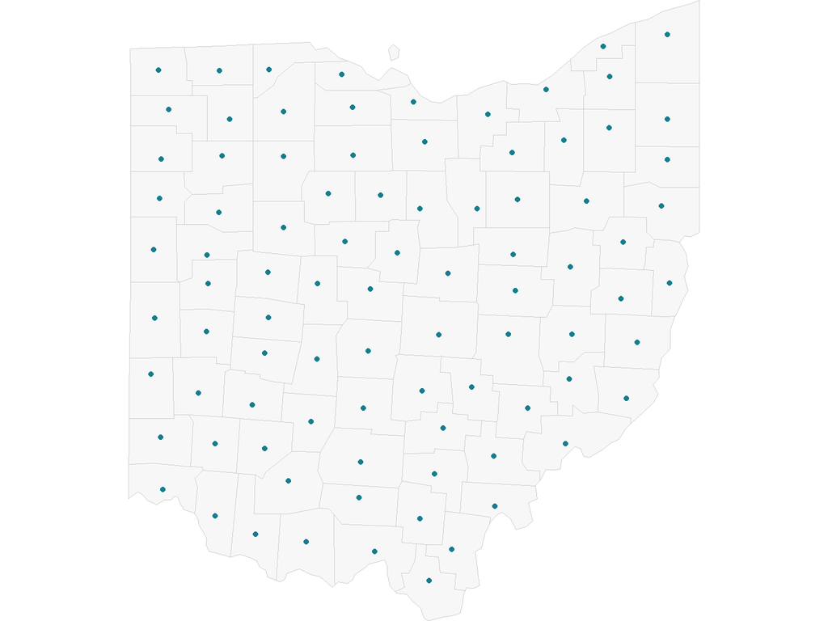

`label_xy[, 1]` supplies X (longitude), and `label_xy[, 2]` supplies Y (latitude). The last `case_when()` nudges two labels horizontally to reduce overlap.

## A County-Level Map - 2

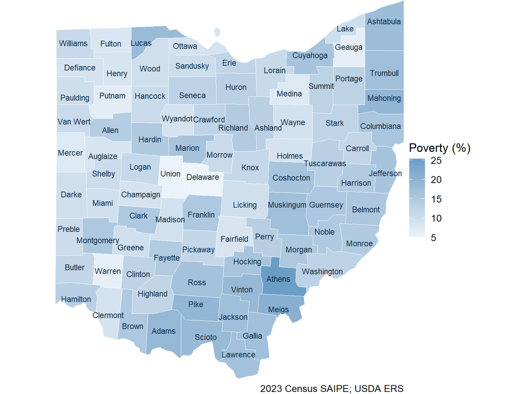

```r
g2 <- ggplot(ohio_sf) +
  geom_sf(aes(fill = poverty_pct),
          colour = "white", linewidth = 0.15) +
  geom_text(data = ohio_labels,
            aes(long, lat, label = label),
            colour = "#102A43", size = 3) +
  coord_sf(crs = st_crs(4326), expand = FALSE) +
  scale_fill_gradient(low = "#EDF4FA",
                      high = "#6B9EC5") +
  labs(fill = "Poverty (%)",
       caption = "2023 Census SAIPE; USDA ERS") +
  theme_void(base_size = 13)

g2
```

- `coord_sf(crs = st_crs(4326))` chooses the displayed coordinate system.
- `expand = FALSE` removes automatic padding around the coordinate range.
- `scale_fill_gradient()` uses light blue for the lowest rates and darker blue for the highest. `low` and `high` set the endpoint colors.

## A County-Level Map: Interaction

The tooltip reports each county’s published estimate. `aes(text = ...)` adds a custom message to the existing map; `tooltip = "text"` selects that message.

```r
g2_hover <- g2 +
  aes(text = paste0(county, ": ", poverty_pct,
                    "% in poverty (2023)"))

ggplotly(g2_hover, tooltip = "text",
         height = 650) %>%
  config(responsive = TRUE,
         displayModeBar = FALSE)
```

[interactive chart not shown]

## Bubble Map: People in Poverty

### The same counties, a different measure

| Map | Visual encoding |
| --- | --- |
| Filled map | Color shows **poverty percentage** |
| Bubble map | Circle area shows **people in poverty** |

```r
bubble_data <- ohio_labels %>%
  arrange(desc(poverty_count))

bubble_data %>%
  select(label, poverty_count, poverty_pct) %>%
  slice_head(n = 5)
```

Draw large circles first. Transparency helps show overlap.

### Largest poverty counts

| County | People | % |
| --- | --- | --- |
| Franklin | 195,004 | 15.1 |
| Cuyahoga | 193,220 | 16.0 |
| Hamilton | 109,421 | 13.6 |
| Montgomery | 79,116 | 15.2 |
| Lucas | 75,810 | 18.2 |

A large count can occur alongside a moderate rate.

Each point represents its **county**, not the locations of individual households.

## Bubble Area and Point Appearance

### Area represents the count

```r
aes(size = poverty_count)

scale_size_area(
  max_size = 18,
  breaks = c(10000, 50000, 100000),
  labels = scales::label_comma()
)
```

`scale_size_area()` makes circle **area** proportional to the value. Twice as many people gives twice the area, not twice the diameter. A value of zero has zero area.

### The arguments used next

| Argument | Meaning |
| --- | --- |
| `max_size` | Largest displayed circle size |
| `breaks` | Reference counts shown in the size legend |
| `labels` | How legend values are formatted |
| `shape = 21` | A circle with separate fill and outline |
| `alpha = 0.65` | Partial transparency, on a 0–1 scale |
| `stroke` | Point-outline thickness |

`scales::label_comma()` formats 10000 as **10,000**. Legend breaks do not filter out other counties.

## Bubble Map

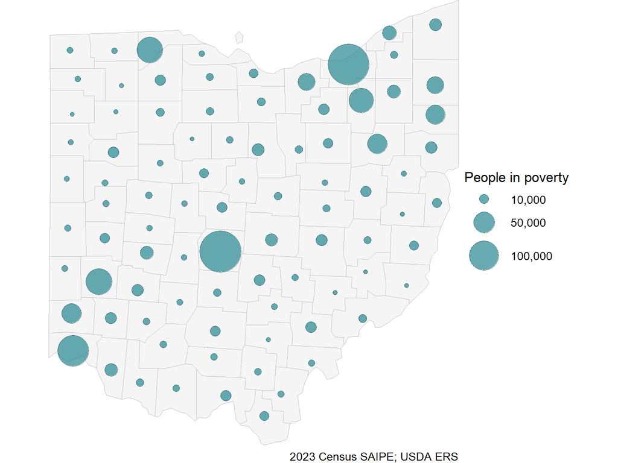

```r
bubble_map <- ggplot(ohio_sf) +
  geom_sf(fill = "grey96", colour = "grey75",
          linewidth = 0.2) +
  geom_point(
    data = bubble_data,
    aes(long, lat, size = poverty_count),
    shape = 21, fill = "#177E89",
    colour = "#144552",
    alpha = 0.65, stroke = 0.3
  ) +
  scale_size_area(
    max_size = 18,
    breaks = c(10000, 50000, 100000),
    labels = scales::label_comma()
  ) +
  coord_sf(crs = st_crs(4326), expand = FALSE) +
  labs(size = "People in poverty",
       caption = "2023 Census SAIPE; USDA ERS") +
  theme_void(base_size = 13)

bubble_map
```

## Bubble Map: Interaction

```r
bubble_hover <- bubble_map +
  aes(text = paste0(county, ": ",
    scales::comma(poverty_count), " people; ",
    poverty_pct, "% (2023)"))

ggplotly(bubble_hover, tooltip = "text",
         height = 650) %>%
  config(responsive = TRUE,
         displayModeBar = FALSE)
```

[interactive chart not shown]

`scales::comma()` formats the count inside each hover message. The message includes both **people** and **percent**, making the distinction visible while students explore.

## Bubble Map: Comparison

### Percentage of people

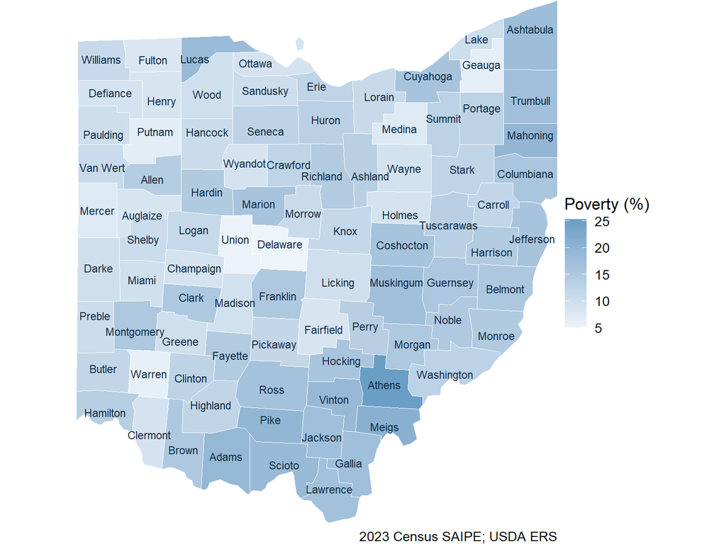

### Number of people

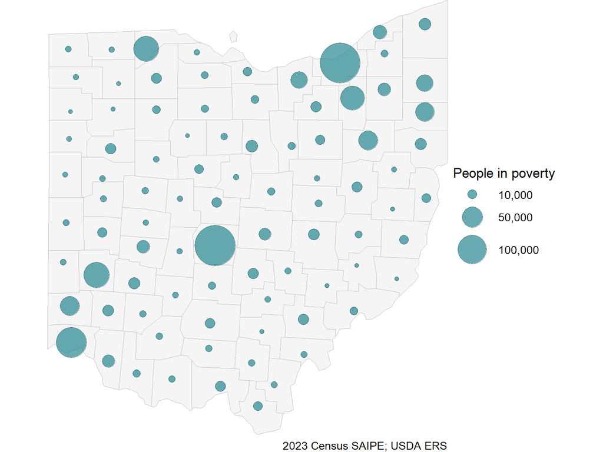

**Discuss:** Do the same counties stand out? Explain why the two maps emphasize different places.

**Practice:** map `median_income` with circle area and revise the legend. What would a larger circle mean?

## Data Sources

- Alcohol consumption: [FiveThirtyEight / WHO GISAH, 2010](https://github.com/fivethirtyeight/data/tree/master/alcohol-consumption)
- State arrests: R’s `USArrests`, 1973
- Ohio poverty and income: `Poverty2023.xlsx`, [Census SAIPE estimates compiled by USDA ERS](https://www.ers.usda.gov/data-products/county-level-data-sets/county-level-data-sets-download-data), 2023
- Boundaries: `maps` and `usmap`

Poverty and income figures are estimates. The original workbook includes 90% confidence intervals.